# Anomaly Detection

*The map is not the territory and data is not the world observed. Data is messy, inconsistent, and unreliable. The world is messier, less consistent, and less reliable.*

–c.f. Alfred Korzybski.

## Missing Data

- Sentinels versus explicit absence
- Semantics of NULL, NaN, and N/A
- Nullable columns in SQL
- Absence in hierarchies
- Pitfalls of sentinels

```python
for n in range(7, 10):
    exp = 2**n
    a = (22/7) ** exp
    b = π ** exp
    # Compute answer in two "equivalent" ways
    res1 = (a * a) / (b * b)
    res2 = (a / b) * (a / b)
    print(f"n={n}:\n  "
          f"method1: {res1:.3f}\n  "
          f"method2: {res2:.3f}")
```

```
n=7:
  method1: 1.109
  method2: 1.109
n=8:
  method1: 1.229
  method2: 1.229
n=9:
  method1: nan
  method2: 1.510
```

### Personal name data

```
| FirstName     | MiddleName    | LastName
|---------------|---------------|---------------
| Polly         | Jean          | Harvey
| Dick          |               | Dale
| Joey          | Santiago      | Alberto
| Chris         | ""            | Knox
| Gibby         | N/A           | Haynes
```

## SQL

In SQL databases, an explicit NULL is available for all column type, but only if a column has been declared as "nullable." This allows a distinction in principle between an explicit NaN for a numeric field and a NULL for missing values.

```
sqlite> .header on
sqlite> .mode column
sqlite> .nullvalue NULL
sqlite> SELECT ROW_NUMBER() OVER (ORDER BY '') "#", amount, description FROM sentinels;
#  amount  description
-  ------  -----------
1  NaN     Not number
2  1.23    A number
3  NULL    A null
4  3.45    Santiago
5  6.78
6  9.01    NULL
```

- Row 1 contains a NaN and a string description;
- Row 2 contains a float value and a string;
- Row 3 contains an SQL NULL and a string;
- Row 4 contains a float value and a string;
- Row 5 contains a float value and an empty string;
- Row 6 contains a float value and a NULL.

## Hierarchical Formats

In formats like JSON that nest data flexibly, there is an obvious way of representing missing data: by not representing it at all. If you perform hierarchical processing, you will need to check for the presence or absence of a given dictionary key at a given level.

```python
json.loads('[NaN, null, Infinity]')  # null becomes Python None
```

```
[nan, None, inf]
```

```python
json_data = '''
{"amount": {"1": NaN, "2": 1.23, "4": 3.45, "5": 6.78, "6": 9.01},
 "description": {"1": "Not number", "2": "A number", "3": "A null",
       "4": "Santiago", "5": ""}
}'''
```

```python
print(pd.read_json(json_data).sort_index())
```

```
   amount description
1     NaN  Not number
2    1.23    A number
3     NaN      A null
4    3.45    Santiago
5    6.78
6    9.01         NaN
```

```python
data = json.loads(json_data)
rows = {row for dct in data.values()
            for row in dct.keys()}

for row in sorted(rows):
    for col in data.keys():
        val = data[col].get(row)
        if val is None:
            print(f"Row {row}, Col {col}: Missing")
        elif isinstance(val, float) and math.isnan(val):
            print(f"Row {row}, Col {col}: Not a Number")
        elif not val:
            print(f"Row {row}, Col {col}: Empty value {repr(val)}")
```

```
Row 1, Col amount: Not a Number
Row 3, Col amount: Missing
Row 5, Col description: Empty value ''
Row 6, Col description: Missing
```

## Sentinel Diversity

```
class BadValue(metaclass=Pretty):
    String = "�"
    StringFromNull = "��"
    EmptyString = ""
    Date = pd.NaT
    # Earliest date in numpy.datetime64
    DateFromNull = pd.to_datetime("1677-09-22")
    Float = float("nan")
    FloatFromNull = -999.99
    Int = -sys.maxsize // 2
    IntFromNull = -sys.maxsize // 4
    Bool = False
```

## Sentinels in the Wild

In textual data formats, mainly delimited and fixed width files, missing data is indicated either by absence or by a sentinel. Both delimited and fixed width formats are able to omit a certain field in a row.

## Sentinels in SQL and DataFrames

Use of sentinels is not limited to text formats. Often in SQL, TEXT or CHAR columns that could use NULL to indicate mising values instead use sentinels.

In Pandas, many strings are interpreted as NULL sentinels: '', '#N/A', '#N/A N/A', '#NA', '-1.#IND', '-1.#QNAN', '-NaN', '-nan', '1.#IND', '1.#QNAN', '', 'N/A', 'NA', 'NULL', 'NaN', 'n/a', 'nan', 'null'

```python
sorstokken = pl.read_csv('data/sorstokken-no.csv.gz')
sorstokken
```

shape: (299, 6)

| STATION i64 | DATE str | TEMP f64 | VISIB f64 | GUST f64 | DEWP f64 |
| --- | --- | --- | --- | --- | --- |
| 1001499999 | "2019-01-01" | 39.7 | 6.2 | 52.1 | 30.4 |
| 1001499999 | "2019-01-02" | 36.4 | 6.2 | 999.9 | 29.8 |
| 1001499999 | "2019-01-03" | 36.5 | 3.3 | 999.9 | 35.6 |
| 1001499999 | "UNKNOWN" | 45.6 | 2.2 | 22.0 | 44.8 |
| 1001499999 | "2019-01-06" | 42.5 | 1.9 | 999.9 | 42.5 |
| … | … | … | … | … | … |
| 1001499999 | "2019-12-16" | 39.1 | 6.2 | 999.9 | 36.8 |
| 1001499999 | "2019-12-17" | 40.5 | 6.2 | 999.9 | 39.2 |
| 1001499999 | "2019-12-18" | 38.8 | 6.2 | 999.9 | 38.2 |
| 1001499999 | "2019-12-19" | 45.5 | 6.1 | 999.9 | 42.7 |
| 1001499999 | "2019-12-20" | 51.8 | 6.2 | 35.0 | 41.2 |

```python
sorstokken.min()
```

shape: (1, 6)

| STATION i64 | DATE str | TEMP f64 | VISIB f64 | GUST f64 | DEWP f64 |
| --- | --- | --- | --- | --- | --- |
| 1001499999 | "2019-01-01" | 27.2 | 1.2 | 17.1 | 16.5 |

```python
sorstokken.max()
```

shape: (1, 6)

| STATION i64 | DATE str | TEMP f64 | VISIB f64 | GUST f64 | DEWP f64 |
| --- | --- | --- | --- | --- | --- |
| 1001499999 | "UNKNOWN" | 88.1 | 999.9 | 999.9 | 63.5 |

```python
for col in ['VISIB', 'GUST']:
    s = sorstokken[col]
    print(col, s.filter(s < 999.9).max(),
          "...standard deviation w/ and w/o sentinel:",
          f"{s.std():.1f} / {s.filter(s < 999.9).std():.1f}")
```

```
VISIB 6.8 ...standard deviation w/ and w/o sentinel: 254.4 / 0.7
GUST 62.2 ...standard deviation w/ and w/o sentinel: 452.4 / 8.1
```

```python
sorstokken = pl.read_csv('data/sorstokken-no.csv.gz',
                         null_values={
                             'DATE': 'UNKNOWN',
                             'VISIB': '999.9',
                             'GUST': '999.9'
                         },
                         try_parse_dates=True)
sorstokken.head()
```

shape: (5, 6)

| STATION i64 | DATE date | TEMP f64 | VISIB f64 | GUST f64 | DEWP f64 |
| --- | --- | --- | --- | --- | --- |
| 1001499999 | 2019-01-01 | 39.7 | 6.2 | 52.1 | 30.4 |
| 1001499999 | 2019-01-02 | 36.4 | 6.2 | null | 29.8 |
| 1001499999 | 2019-01-03 | 36.5 | 3.3 | null | 35.6 |
| 1001499999 | null | 45.6 | 2.2 | 22.0 | 44.8 |
| 1001499999 | 2019-01-06 | 42.5 | 1.9 | null | 42.5 |

## Miscoded Data

- Categorical and ordinal constraints
- Encoded values and metadata definitions
- Rare categories

```python
from src.dermatology import *
(pd.DataFrame(
    [derm.min(), derm.max(), derm.dtypes])
     .T
     .rename(columns={0:'min', 1:'max', 2:'dtype'})
).tail(10)
```

|  | min | max | dtype |
| --- | --- | --- | --- |
| disappearance of the granular layer | 0 | 3 | int64 |
| vacuolisation and damage of basal layer | 0 | 3 | int64 |
| spongiosis | 0 | 3 | int64 |
| saw-tooth appearance of retes | 0 | 3 | int64 |
| follicular horn plug | 0 | 3 | int64 |
| perifollicular parakeratosis | 0 | 3 | int64 |
| inflammatory monoluclear inflitrate | 0 | 3 | int64 |
| band-like infiltrate | 0 | 3 | int64 |
| Age | 0.0 | 75.0 | float64 |
| TARGET | cronic dermatitis | seboreic dermatitis | object |

```python
humans = pd.read_csv('data/humans-err.csv')
# random_state for deterministic sample
humans.sample(5, random_state=1)
```

|  | Height | Weight | Hair_Length | Favorite |
| --- | --- | --- | --- | --- |
| 21492 | 176.958650 | 72.604585 | 14.0 | red |
| 9488 | 169.000221 | 79.559843 | 0.0 | blue |
| 16933 | 171.104306 | 71.125528 | 5.5 | red |
| 12604 | 174.481084 | 79.496237 | 8.1 | blue |
| 8222 | 171.275578 | 77.094118 | 14.6 | green |

```python
humans.Favorite.unique()
```

```
array(['red', 'green', 'blue', 'Red', ' red', 'grееn', 'blüe',
       'chartreuse'], dtype=object)
```

```python
humans.Favorite.value_counts()
```

```
Favorite
red           9576
blue          7961
green         7458
Red              1
 red             1
grееn            1
blüe             1
chartreuse       1
Name: count, dtype: int64
```

```python
for color in sorted(humans.Favorite.unique()):
    print(f"{color:>10s}", [ord(c) for c in color])
```

```
       red [32, 114, 101, 100]
       Red [82, 101, 100]
      blue [98, 108, 117, 101]
      blüe [98, 108, 252, 101]
chartreuse [99, 104, 97, 114, 116, 114, 101, 117, 115, 101]
     green [103, 114, 101, 101, 110]
     grееn [103, 114, 1077, 1077, 110]
       red [114, 101, 100]
```

```python
humans.loc[humans.Favorite.isin(['Red', ' red']), 'Favorite'] = 'red'
humans.loc[humans.Favorite == 'chartreuse', 'Favorite'] = None
humans.loc[humans.Favorite == 'blüe', 'Favorite'] = 'blue'
humans.loc[humans.Favorite == 'grееn', 'Favorite'] = 'green'
humans.Favorite.value_counts()
```

```
Favorite
red      9578
blue     7962
green    7459
Name: count, dtype: int64
```

## Fixed Bounds

- Domain versus measurement limits
- Imputation and clipping
- Improbability versus impossibility
- Exploring hypotheses for data errors

```python
((humans.Height < 92) | (humans.Height > 213)).any()
```

```
False
```

```python
humans.query('Hair_Length > 120')
```

|  | Height | Weight | Hair_Length | Favorite |
| --- | --- | --- | --- | --- |
| 1984 | 165.634695 | 62.979993 | 127.0 | red |
| 8929 | 175.186061 | 73.899992 | 120.6 | blue |
| 14673 | 174.948037 | 77.644434 | 130.1 | blue |
| 14735 | 176.385525 | 68.735397 | 121.7 | green |
| 16672 | 173.172298 | 71.814699 | 121.4 | red |
| 17093 | 169.771111 | 77.958278 | 133.2 | blue |

```python
humans2 = humans.copy()  # Retain prior versions of data set
humans2['Hair_Length'] = humans2.Hair_Length.clip(upper=120)
humans2[humans2.Hair_Length > 119]
```

|  | Height | Weight | Hair_Length | Favorite |
| --- | --- | --- | --- | --- |
| 1984 | 165.634695 | 62.979993 | 120.0 | red |
| 4146 | 173.930107 | 72.701456 | 119.6 | red |
| 8929 | 175.186061 | 73.899992 | 120.0 | blue |
| 9259 | 179.215974 | 82.538890 | 119.4 | green |
| 14673 | 174.948037 | 77.644434 | 120.0 | blue |
| 14735 | 176.385525 | 68.735397 | 120.0 | green |
| 16672 | 173.172298 | 71.814699 | 120.0 | red |
| 17093 | 169.771111 | 77.958278 | 120.0 | blue |

```python
humans2[humans2.Hair_Length == 0]
```

|  | Height | Weight | Hair_Length | Favorite |
| --- | --- | --- | --- | --- |
| 6 | 177.297182 | 81.153493 | 0.0 | blue |
| 217 | 171.893967 | 68.553526 | 0.0 | blue |
| 240 | 161.862237 | 76.914599 | 0.0 | blue |
| 354 | 172.972247 | 73.175032 | 0.0 | red |
| 371 | 179.866011 | 80.418554 | 0.0 | red |
| ... | ... | ... | ... | ... |
| 24818 | 171.537554 | 72.619095 | 0.0 | green |
| 24834 | 170.991301 | 67.652660 | 0.0 | green |
| 24892 | 177.002643 | 77.286141 | 0.0 | green |
| 24919 | 169.012286 | 74.593809 | 0.0 | blue |
| 24967 | 169.061308 | 65.985481 | 0.0 | green |

517 rows × 4 columns

```python
neg_hair = humans2[humans2.Hair_Length < 0]
neg_hair
```

|  | Height | Weight | Hair_Length | Favorite |
| --- | --- | --- | --- | --- |
| 493 | 167.703398 | 72.567763 | -1.0 | blue |
| 528 | 167.355393 | 60.276190 | -20.7 | green |
| 562 | 172.416114 | 60.867457 | -68.1 | green |
| 569 | 177.644146 | 74.027147 | -5.9 | green |
| 738 | 178.094818 | 76.963924 | -57.2 | blue |
| ... | ... | ... | ... | ... |
| 24042 | 174.608922 | 64.846422 | -22.7 | green |
| 24055 | 172.831608 | 74.096660 | -13.3 | red |
| 24063 | 172.687488 | 69.466838 | -14.2 | green |
| 24386 | 176.668430 | 62.984811 | -1.0 | green |
| 24944 | 172.300925 | 72.067862 | -24.4 | red |

118 rows × 4 columns

```python
neg_hair.Hair_Length.describe()
```

```
count    118.000000
mean     -24.348305
std       22.484691
min      -95.700000
25%      -38.075000
50%      -20.650000
75%       -5.600000
max       -0.700000
Name: Hair_Length, dtype: float64
```

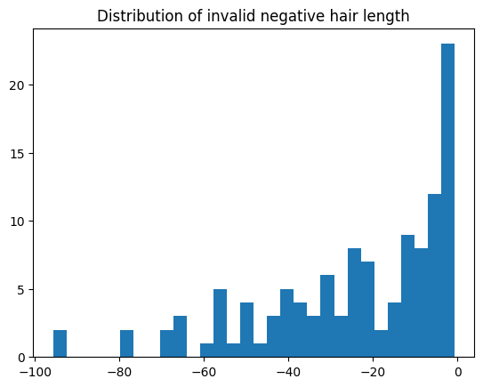

```python
plt.hist(neg_hair.Hair_Length, bins=30)
plt.title("Distribution of invalid negative hair length");
```

```python
neg_hair.Hair_Length.value_counts()
```

```
Hair_Length
-1.0     19
-8.5      2
-30.1     2
-6.8      2
-10.9     2
         ..
-30.5     1
-67.5     1
-40.6     1
-7.0      1
-39.3     1
Name: count, Length: 93, dtype: int64
```

```python
humans3 = humans2.copy()     # Versioned changes to data

# The "sentinel" negative value means missing
humans3.loc[humans3.Hair_Length == -1, 'Hair_Length'] = None

# All other values simply become non-negative
humans3['Hair_Length'] = humans3.Hair_Length.abs()
```

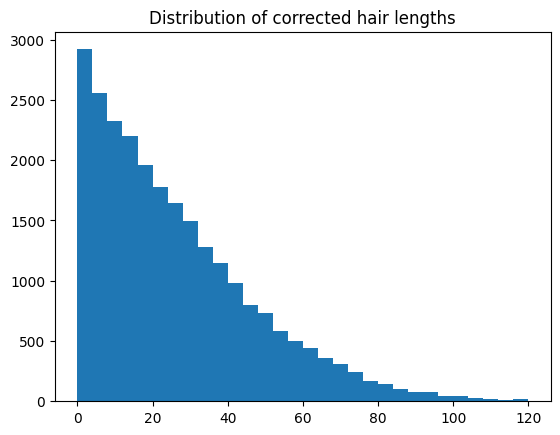

```python
plt.hist(humans3.Hair_Length, bins=30)
plt.title("Distribution of corrected hair lengths");
```

## Outliers

- Z-score and unexpected values
- Interquartile range
- Standard deviation and frequency of occurrence

### Z-score formula

$$Z = \frac{x - \mu}{\sigma}$$

Where $\mu$ is sample mean, and $\sigma$ is standard deviation.

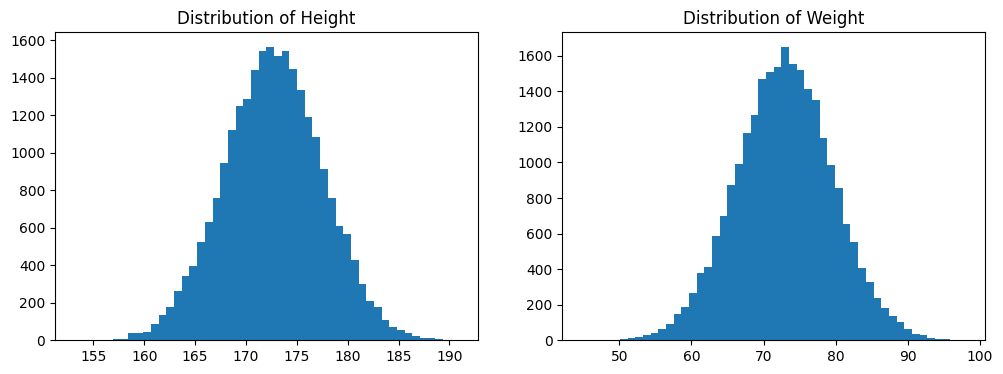

```python
fig, (ax1, ax2) = plt.subplots(1, 2, figsize=(12, 4))
ax1.hist(humans3.Height, bins=50)
ax2.hist(humans3.Weight, bins=50)
ax1.set_title("Distribution of Height")
ax2.set_title("Distribution of Weight")
```

```python
from scipy.stats import anderson

for var in ('Height', 'Weight', 'Hair_Length'):
    data = humans3[var][humans3[var].notnull()]
    stat = anderson(data, 'norm').statistic
    print(f"Anderson-Darling statistic for {var:<12s}: {stat:6.2f}")
```

```
Anderson-Darling statistic for Height      :   0.24
Anderson-Darling statistic for Weight      :   0.54
Anderson-Darling statistic for Hair_Length : 578.19
```

```python
humans4 = humans3.copy()

for var in ('Height', 'Weight', 'Hair_Length'):
    zscore = (humans4[var] - humans4[var].mean()) / humans4[var].std()
    humans4[f"zscore_{var}"] = zscore

humans4.sample(5, random_state=1)
```

|  | Height | Weight | Hair_Length | Favorite | zscore_Height | zscore_Weight | zscore_Hair_Length |
| --- | --- | --- | --- | --- | --- | --- | --- |
| 21492 | 176.958650 | 72.604585 | 14.0 | red | 0.880831 | -0.042032 | -0.568786 |
| 9488 | 169.000221 | 79.559843 | 0.0 | blue | -0.766210 | 0.997585 | -1.225152 |
| 16933 | 171.104306 | 71.125528 | 5.5 | red | -0.330758 | -0.263109 | -0.967294 |
| 12604 | 174.481084 | 79.496237 | 8.1 | blue | 0.368085 | 0.988078 | -0.845397 |
| 8222 | 171.275578 | 77.094118 | 14.6 | green | -0.295312 | 0.629028 | -0.540656 |

```python
print("Unusual heights:",
      len(humans4[humans4.zscore_Height.abs() > 3]))
humans4[humans4.zscore_Height.abs() > 3].sample(10)
```

```
Unusual heights: 51
```

|  | Height | Weight | Hair_Length | Favorite | zscore_Height | zscore_Weight | zscore_Hair_Length |
| --- | --- | --- | --- | --- | --- | --- | --- |
| 9492 | 188.109733 | 76.750106 | 32.7 | red | 3.188608 | 0.577608 | 0.307932 |
| 412 | 157.522316 | 62.564977 | 6.8 | blue | -3.141625 | -1.542673 | -0.906345 |
| 24244 | 158.153049 | 59.725932 | 13.8 | green | -3.011091 | -1.967031 | -0.578162 |
| 10635 | 187.669780 | 77.991486 | 37.7 | green | 3.097558 | 0.763159 | 0.542348 |
| 15209 | 189.483822 | 84.332363 | 2.8 | red | 3.472984 | 1.710944 | -1.093878 |
| 22471 | 189.275314 | 84.303399 | 23.1 | green | 3.429832 | 1.706614 | -0.142148 |
| 13971 | 153.107034 | 63.155154 | 4.4 | green | -4.055392 | -1.454458 | -1.018865 |
| 24801 | 189.310696 | 85.406727 | 2.3 | green | 3.437154 | 1.871531 | -1.117320 |
| 14106 | 157.244415 | 45.062151 | 70.7 | red | -3.199138 | -4.158856 | 2.089496 |
| 11173 | 188.386644 | 81.886770 | 2.0 | green | 3.245917 | 1.345396 | -1.131385 |

```python
print("Outlier weight:", (humans4.zscore_Weight.abs() > 3).sum())
print("Outlier hair length:", (humans4.zscore_Hair_Length.abs() > 3).sum())
```

```
Outlier weight: 67
Outlier hair length: 285
```